# sst_post_error_slowing

Steps:

- load file
- number each trial consecutively based on the onset time
- number the following trial for each trial
- merge the file with itself, merging each trial with its following trial
- for each measure the post-trial time for a correct result

This paper probably has a good method, ‘How to measure post-error slowing: A confound and a simple solution’,

Look at their “simple solution”, and follow the method there. https://www.sciencedirect.com/science/article/abs/pii/S0022249612000454 https://www.sciencedirect.com/science/article/pii/S0022249612000454

https://www.frontiersin.org/articles/10.3389/fpsyg.2014.00119/full

For the variables, see https://www.dropbox.com/scl/fi/acc3pmvb28b9swz0cnr82/Info-about-Stop-Signal-Task-Baseline-Analysis.docx?dl=0&rlkey=18mfzinj70pmuhdv8d00nh84e found in /Berkman Lab/Devaluation/Papers/Frontiers - Health Special Issue we should use: PostErrorSlowW1_mean PostErrorSlowW1_median not sst_pes_limited

## load file

```r
library(ggplot2)
```

```r
Sys.setenv(R_CONFIG_ACTIVE = Sys.info()["nodename"])
dropbox_file_dir = config::get("dev_analysis_data_dir")
sst_all_data_filepath <- "~/Dropbox (University of Oregon)/UO-SAN Lab/Berkman Lab/Devaluation/analysis_files/data/sst_behavioral_data_all.csv"

sst_all_data_raw <- readr::read_csv(sst_all_data_filepath)
```

```r
library(dplyr)
```

## About the Stop Signal Task

Task format The participant must respond to an arrow stimulus, by selecting one of two options, depending on the direction in which the arrow points. If an audio tone is present, the subject must withhold making that response (inhibition). The test consists of two parts: In the first part, the participant is introduced to the test and told to select the left-hand button when they see a left-pointing arrow and the right-hand button when they see a right-pointing arrow. There is one block of 16 trials for the participant to practice this. In the second part, the participant is told to continue selecting the buttons when they see the arrows but, if they hear an auditory signal (a beep), they should withhold their response and not select the button. Go task (e.g. press left when an arrow pointing to the left appears, and right when an arrow pointing to the right appears) Stop signal (e.g. a cross replacing the arrow OR a tone?) appears after a variable stop-signal delay (SSD), instructing participants to suppress the imminent go response.  
Conceptualizes the ability to inhibit the response as a race between a Go- and a Stop process that are triggered by the presentation of the Go and Stop-signal, respectively. If the Go process finishes first, the response will be executed. If the Stop process finishes first, the response will be inhibited (Teichert, 2015). Condition Type 1 CorrectGo (i.e. pressed left when an arrow pointing to the left appears, and right when an arrow pointing to the right appears) 2 FailedGo (i.e. did NOT press left when an arrow pointing to the left appears, and right when an arrow pointing to the right appears) 3 CorrectStop (i.e. Suppressed the go response) 4 FailedStop: (i.e. Failed to suppressed the go response)

### Calculate with respect to the pre-stop trial so that we can measure slowing/speeding in CS

We can be agnostic about it. simply record, for every trial where there is a reaction time before and after the trial, regardless of the trial type, what was the change?

First, we need to clean RTs

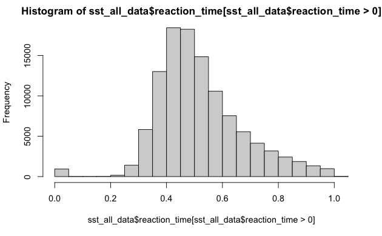

```r
sst_all_data<-sst_all_data_raw
sst_all_data$reaction_time_clean<-sst_all_data$reaction_time
sst_all_data$reaction_time_clean[sst_all_data$reaction_time==0]<-NA

hist(sst_all_data$reaction_time[sst_all_data$reaction_time>0.0])
```

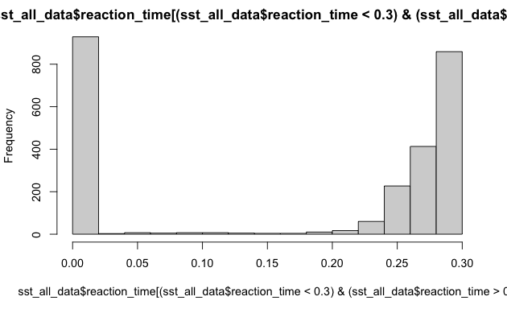

```r
hist(sst_all_data$reaction_time[(sst_all_data$reaction_time<0.3) & (sst_all_data$reaction_time>0.0)])
```

Based on eyeballing this histogram, reaction times start to increase around 0.2. So let’s make the cut-off at 0.15. Less than that, and they aren’t really a reaction.

```r
sst_all_data$reaction_time_clean[sst_all_data$reaction_time_clean<0.15]<-NA
```

```r
sst_all_data<-
  sst_all_data %>%
  mutate(has_response=!is.na(reaction_time_clean)) %>%
  mutate(follows_response_trial=lag(has_response,2),
         precedes_response_trial=lead(has_response,2)
         ) %>%
  mutate(post_pre_rt_change=lead(reaction_time_clean,2)-lag(reaction_time_clean,2))

#right. now we can view distributions of post_pre_rt_change by condition
ggplot(sst_all_data %>% filter(condition!="Cue"),
       aes(x=post_pre_rt_change,fill=condition))+
  geom_histogram()+facet_wrap(~condition,scales = "free")+
  geom_vline(xintercept=0)
```

[output not shown]

```r
for(cond in unique(sst_all_data$condition)){
  if(cond=="Cue"){next}
  print(cond)
  print("post minus pre trial reaction time change")
  sst_all_data_condition<-sst_all_data %>% filter(condition==cond)
  print(t.test(sst_all_data_condition$post_pre_rt_change))
}
```

```
[1] "CorrectGo"
[1] "post minus pre trial reaction time change"

    One Sample t-test

data:  sst_all_data_condition$post_pre_rt_change
t = -25.035, df = 72203, p-value < 2.2e-16
alternative hypothesis: true mean is not equal to 0
95 percent confidence interval:
 -0.01418708 -0.01212698
sample estimates:
  mean of x
-0.01315703

[1] "FailedStop"
[1] "post minus pre trial reaction time change"

    One Sample t-test

data:  sst_all_data_condition$post_pre_rt_change
t = 26.966, df = 11107, p-value < 2.2e-16
alternative hypothesis: true mean is not equal to 0
95 percent confidence interval:
 0.03697496 0.04277171
sample estimates:
 mean of x
0.03987334

[1] "CorrectStop"
[1] "post minus pre trial reaction time change"

    One Sample t-test

data:  sst_all_data_condition$post_pre_rt_change
t = 11.539, df = 9330, p-value < 2.2e-16
alternative hypothesis: true mean is not equal to 0
95 percent confidence interval:
 0.01515258 0.02135403
sample estimates:
mean of x
0.0182533

[1] "FailedGo"
[1] "post minus pre trial reaction time change"

    One Sample t-test

data:  sst_all_data_condition$post_pre_rt_change
t = -13.21, df = 1547, p-value < 2.2e-16
alternative hypothesis: true mean is not equal to 0
95 percent confidence interval:
 -0.07171381 -0.05317069
sample estimates:
  mean of x
-0.06244225
```

```r
#what about only if it's a trial preceded and followed by a CG trial?
```

This is kind of against my hypothesis. I thought that in CorrectStop trials, subjects would update that they have correct impulses in the trials and can therefore respond *faster* in subsequent trials. But overall, they don’t do that. Instead, after a correctstop trial, reaction time *increases*, probably because subjects use the trial as evidence of more Stop trials and therefore respond by slowing down.

However, it is possible that there is more than one evidential process happening, and they countervail.

In FailedStop trials, subjects increase their reaction times, by even more, because they want to avoid making an error. This can be seen as the compound of:

so in CS trials, you have

but you do not have a punished response.

in CG trials:

- evidence that Stop trials occur decreases, DECREASING reaction time
- reward of Go response occurs, DECREASING raction time

No tone delay change in these trials.

In FG trials: - punishment of no go occurs, DECREASING reaction time

So when calculating when it is rational to respond, you need to consider: - prior probability that a trial is a stop trial - prior probability, given a certain amount of evidence accumulated, that the trial is a stop trial - adjustment of the tone delay

Together these three factors could predict behavior.

This model might need revision if it turns out participants are told in advance that the amount of Correct Stop trials will match the amount of Failed Stop trials. I don’t think they are.

Let’s calculate this. First, the prior probability that a trial is a stop trial, given all the evidence gathered by the participant:

```r
sst_all_data <- sst_all_data %>% group_by(subid,waveid,runid) %>%
  mutate(
    CumulativeGoTrials=cumsum(go_no_go_condition_label=="Go"),
    CumulativeStopTrials=cumsum(go_no_go_condition_label=="Stop")
  ) %>% mutate(
    PP_IsGo=(lag(CumulativeGoTrials,2)/
      (lag(CumulativeGoTrials,2)+lag(CumulativeStopTrials,2))
    ),
    PP_IsStop=(lag(CumulativeStopTrials,2)/
      (lag(CumulativeGoTrials,2)+lag(CumulativeStopTrials,2))
    )
  )

#table(sst_all_data$go_no_go_condition_label,sst_all_data$condition)

#sst_all_data %>% select(subid,waveid,trial_number,go_no_go_condition_label,condition,CumulativeGoTrials,CumulativeStopTrials,PP_IsGo,PP_IsStop)
```

Then we have subjective uncertainty around when a tone occurs, given that we are in a stop trial and a tone will occur $P(t_o|S)$. Let’s say it’s a normal distribution with mean $\mu_t$, sd $\sigma_t$, $N(\mu_t,\sigma_t)$. Given $\mu_t$ and $\sigma_t$, we calculate the probability, given we’re in a stop trial, of a tone occuring as modeled by that normal distribution, $P(T_t|S)=N(\mu_t,\sigma_t)$. Combined with the prior probability of a tone occuring, $P(S)$, we can calculate the posterior likelihood of $P(S)$ as:

$\mu_t$ will be the past observations of tone times, while $\sigma_t$ is the subjective error in perception of tone delay; uncertain how to quantify this but we could make it $\sigma_t=0.15\text{ s}$ to start.

More generally $\mu_t$ would be some function of all the past tone times, somewhere between an average of all of them, and the latest tone time. As a compromise let’s define it as the average of each.

Then let’s define our $\mu_t$ as

```r
lag(1:10,2)
```

```
 [1] NA NA  1  2  3  4  5  6  7  8
```

```r
sst_all_data[,c("trial_duration","condition")]
```

| trial_duration | condition |
| --- | --- |
| 2.25834 | CorrectGo |
| 0.75000 | Cue |
| 2.00556 | FailedStop |
| 1.37500 | Cue |
| 2.25834 | CorrectGo |
| 3.12500 | Cue |
| 2.00556 | FailedStop |
| 1.87500 | Cue |
| 2.13195 | CorrectGo |
| 2.75000 | Cue |

[output cut: 990 more lines]

```r
sst_all_data$last_tone_delay<-NA
sst_all_data <-sst_all_data %>% group_by(subid,waveid,runid) %>%
  mutate(
    last_tone_delay=case_when(
      lag(SSD_recorded,1)>0 ~lag(SSD_recorded,1),
      TRUE ~ as.numeric(NA)
    )
  ) %>%
  tidyr::fill(last_tone_delay,.direction="down")

sst_all_data <- sst_all_data %>% group_by(subid,waveid,runid) %>%
  mutate(SSD_event_prior = lag(SSD_recorded,1)>0) %>%
  mutate(lagged_tone_delay = lag(SSD_recorded,1)) %>%
  mutate(average_tone_delay = (
    cumsum(ifelse(is.na(lagged_tone_delay),0,lagged_tone_delay))/
      cumsum(ifelse(is.na(SSD_event_prior),0,SSD_event_prior))
  ))





#sst_all_data$expected_tone_delay<-rowMeans(sst_all_data[,c("last_tone_delay", "average_tone_delay")])
#probably more rational, given what the task actually is, and also easier
sst_all_data$expected_tone_delay<-sst_all_data$last_tone_delay
```

*so perhaps we can predict putamen activity by the combination of $P(~T_t)$ and $P(T_t|S)=N(\mu_t,\sigma_t)$, or simpler representations of derivatives thereof. maybe just a linear model of….*

Simplest explanation might just be: Go response punishment [internal penalty] follows a FS trial, whereas NoGo inhibition reward follows a CS trial. The punishment is enough to inhibit putamen response.

I really want to do that sample of activity right from the point the subject learns they were right or wrong. So we get the timing of every single trial, synhronize, and graph the succession of responses using a moving average following FS, CS, FG, CG.

[output not shown]

```r
sst_all_data<-
  sst_all_data %>%
  #mutate(has_response=!is.na(reaction_time_clean)) %>%
  # mutate(follows_response_trial=lag(has_response,2),
  #        precedes_response_trial=lead(has_response,2)
  #        ) %>%
  mutate(post_pre_E_t_delay_change=lead(expected_tone_delay,2)-lag(expected_tone_delay,2))

#right. now we can view distributions of post_pre_rt_change by condition
ggplot(sst_all_data %>% filter(condition!="Cue"),
       aes(x=post_pre_E_t_delay_change,fill=condition))+
  geom_histogram()+facet_wrap(~condition,scales = "free")+
  geom_vline(xintercept=0)
```

[output not shown]

```r
for(cond in unique(sst_all_data$condition)){
  if(cond=="Cue"){next}
  print(cond)
  print("post minus pre trial reaction time change")
  sst_all_data_condition<-sst_all_data %>% filter(condition==cond)
  print(t.test(sst_all_data_condition$post_pre_E_t_delay_change))
}
```

```
[1] "CorrectGo"
[1] "post minus pre trial reaction time change"

    One Sample t-test

data:  sst_all_data_condition$post_pre_E_t_delay_change
t = 4.6021, df = 90204, p-value = 4.188e-06
alternative hypothesis: true mean is not equal to 0
95 percent confidence interval:
 0.0003600232 0.0008941757
sample estimates:
   mean of x
0.0006270994

[1] "FailedStop"
[1] "post minus pre trial reaction time change"

    One Sample t-test

data:  sst_all_data_condition$post_pre_E_t_delay_change
t = 14.687, df = 15580, p-value < 2.2e-16
alternative hypothesis: true mean is not equal to 0
95 percent confidence interval:
 0.008398916 0.010986036
sample estimates:
  mean of x
0.009692476

[1] "CorrectStop"
[1] "post minus pre trial reaction time change"

    One Sample t-test

data:  sst_all_data_condition$post_pre_E_t_delay_change
t = -17.508, df = 15026, p-value < 2.2e-16
alternative hypothesis: true mean is not equal to 0
95 percent confidence interval:
 -0.01375535 -0.01098548
sample estimates:
  mean of x
-0.01237041

[1] "FailedGo"
[1] "post minus pre trial reaction time change"

    One Sample t-test

data:  sst_all_data_condition$post_pre_E_t_delay_change
t = 5.2931, df = 3464, p-value = 1.278e-07
alternative hypothesis: true mean is not equal to 0
95 percent confidence interval:
 0.003095504 0.006738022
sample estimates:
  mean of x
0.004916763
```

```r
#what about only if it's a trial preceded and followed by a CG trial?
```

## empirical distribution of P_S_given_T_at_rt

Now we know all this, we could calculate $P(S|~T_t)$, but what $t$ do we want to know about? perhaps we could calculate the expected probability of a tone at the instant the subject presses a button, when they press it. This would be….

[figure not shown]

## empirical distribution of P_S_given_T_at_tone

We can also calculate the probability of a tone at the instant the subject hears it….

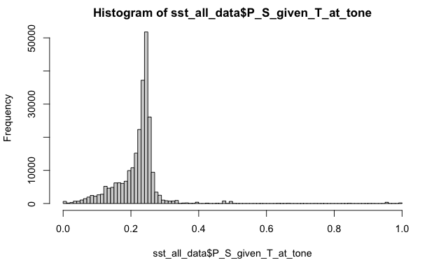

```r
#let's add time for the participant to actually move
sst_all_data$P_T_at_tone_given_S<-1-pnorm(sst_all_data$SSD_recorded,sst_all_data$expected_tone_delay,0.15)
#then the prior probability of S
sst_all_data$P_S_given_T_at_tone<-sst_all_data$PP_IsStop*sst_all_data$P_T_at_tone_given_S

hist(sst_all_data$P_S_given_T_at_tone,breaks=100)
```

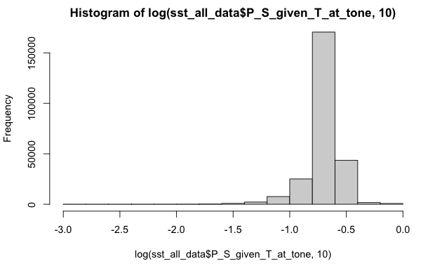

```r
hist(log(sst_all_data$P_S_given_T_at_tone,10))
```

### learning rate

Bernice suggests: subjects differ from rationality in a couple of different ways

These might be the learning rate $P(S)$ and $P(\neg T_t|S)$

### can we model this?

So that looks like an exponential distribution…could also be modeled as Gamma or weibull…

[figure not shown]

[figure not shown]

```r
res<-fitdistr(x_vec, dexp, start=list(rate=1))
```

```
one-dimensional optimization by Nelder-Mead is unreliable:
use "Brent" or optimize() directly
```

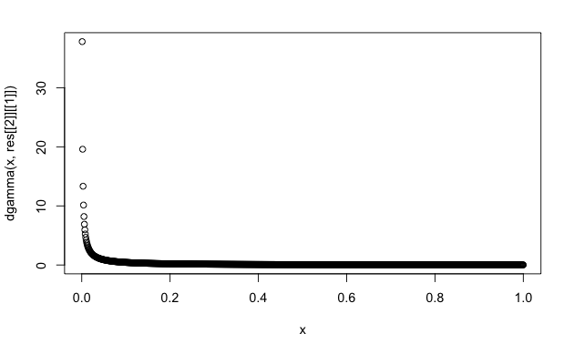

```r
plot(x,dgamma(x,res[[2]][[1]]))
```

```r
dexp(c(0.1,0.5,0.9),1)
```

```
[1] 0.9048374 0.6065307 0.4065697
```

### different tack, transform back to normal????

```r
print(mean(log(-log(sst_all_data$P_S_given_T_at_rt,10)),na.rm = TRUE))
```

```
[1] 0.3712696
```

```r
print(sd(log(-log(sst_all_data$P_S_given_T_at_rt,10)),na.rm = TRUE))
```

```
[1] 0.4373033
```

So at that point, when the subject hears a tone, they will move quickly from the prior probability to near-certainty that this is a stop trial (because they have heard the tone).

# Within subject

How much variance is within-subject vs. between-subject? And do subjects change their probability thresholds over time?

```r
#across-subject variance
sst_all_data$P_S_given_T_at_rt
```

# Figuring out the SSD definitions…

```r
table(sst_all_data$SSD_technical)
table(sst_all_data$SSD_observed)
table(sst_all_data$condition, sst_all_data$SSD_recorded>0)
table(sst_all_data$condition, sst_all_data$SSD_recorded>0)
```

```r
sst_all_data[sst_all_data$condition=="FailedStop",]
```

```r
sst_all_data[sst_all_data$condition=="FailedStop",c("ladder_number","LadderX_SSD_ms","SSD_recorded", "reaction_time")]
```

```r
sst_all_data <- sst_all_data %>% group_by(subid,waveid,runid) %>%
  mutate(SSD_event_prior = lag(SSD_recorded,1)>0) %>%
  mutate(lagged_tone_delay = lag(SSD_recorded,1)) %>%
  mutate(average_tone_delay = (
    cumsum(ifelse(is.na(lagged_tone_delay),0,lagged_tone_delay))/
      cumsum(ifelse(is.na(SSD_recorded),0,SSD_recorded))
  ))
```

Okay, so LadderX_SSD_ms is actually the planned SSD. For the few Stop trials where there is no stop signal (I don’t know why this happens!) we can look at LadderX_SSD_ms to figure out what it should have been.

```r
sst_rtgt0<-sst_all_data[sst_all_data$reaction_time>0,]
table(sst_rtgt0$condition, sst_rtgt0$SSD_recorded>0,sst_rtgt0$ReactionBeforeLadderScheduled)
```

```r
plot(sst_all_data$LadderX_SSD_ms,sst_all_data$SSD_recorded)
```